# Coursework Report

*N* removed NAs: 4

*N* removed <18: 35

**Correct typo age:** 26

*N* total clean: 129

| Group | *N* | *M*<sub>age</sub> | % green |
| --- | --- | --- | --- |
| Control | 68 | 21.4 | 33.8 |
| Experim | 61 | 21.1 | 54.6 |

| Gender | *N* | *M*<sub>age</sub> | % green |
| --- | --- | --- | --- |
| Female | 65 | 21.7 | 44.6 |
| Male | 38 | 20.8 | 49.1 |
| Other | 26 | 21.1 | 33.3 |

**Main analysis results**

**car:**  
χ<sup>2</sup>(1) = 2.05, *p* = .153

**cleaner:**  
χ<sup>2</sup>(1) = 6.43, *p* = .011

**dishwasher:**  
χ<sup>2</sup>(1) = 7.09, *p* = .008

[interactive chart not shown]

[figure not shown]

[interactive chart not shown]

# Coursework Report

Analysing Data, Spring 2020

# Methods

## Participants

Table 1 *Descriptive statistics of Age*

| *N* | *M*<sub>age</sub> | *SD*<sub>age</sub> | *IQR*<sub>age</sub> |
| --- | --- | --- | --- |
| 362 | 21.5 | 2.27 | 3 |

## Design

The study was conducted to investigate the effects of triggering status motives on a subsequent choice of either a luxury product or a more environmentally friendly alternative. Two conditions were used, with a between-subject design. The first of these was the status condition, whereby participants read a short story centred around the ways someone may go about getting a promotion, including pro-social and environmental behaviour. The purpose of this story was to get the participant to consider their own status and how this may be improved upon. The second condition was the control condition, in which the short story read by the participants made no reference to the gaining of status, instead focusing on a missing concert ticket.

The following table shows the age descriptive of the participants by both gender and experimental condition.

Table 2 *Descriptive statistics of Age by Gender and Condition*

| Gender | Condition | *N* | % | *M*<sub>age</sub> | *SD*<sub>age</sub> |
| --- | --- | --- | --- | --- | --- |
| Male | Control Story | 102 | 28.18 | 21.9 | 2.44 |
| Male | High-Status Story | 84 | 23.20 | 21.8 | 2.64 |
| Female | Control Story | 47 | 12.98 | 20.9 | 1.97 |
| Female | High-Status Story | 57 | 15.75 | 21.1 | 2.09 |
| Other | Control Story | 45 | 12.43 | 21.6 | 1.88 |
| Other | High-Status Story | 27 | 7.46 | 20.9 | 1.22 |

After reading these stories, participants completed a survey asking whether they would be more likely to buy the luxury or green version of three products: a car, a cleaner and a dishwasher. The product selected by the participant would be the categorical dependent variable. Both versions were given the same price, to eliminate cost as a possible confounding variable, but one was clearly labelled as more advanced in terms of performance whilst the other was more basic but environmentally friendly. The green products were also associated with higher levels of pro-sociality in a previous study, to strengthen internal validity (Griskevicius, Tybur and Van den Bergh’s, 2010). Whilst it was predicted that the luxury product would be more frequently selected in the control story condition due to perceived higher desirability, the hypothesis states that through activating status motivations by reading the high-status story, participants would more frequently choose the green version of each product in order to promote their own prosocial behaviour. The frequency of the green product selection gave an interpretation of the effect that the high-status story had. A Chi-Squared analysis will be performed in order to test the significance of these results.

# Results

## Car

For the choice of car, the final data shows that there was no association between the condition the participant was in and whether they selected the luxury or green product. In both conditions, a higher majority of participants selected the luxury product, with 65% of the control group and 52% of the high-status group. Despite this figure being lower in the high-status group, it is interpreted that the story type read did not have an effect on subsequent choice.

The counts of product choice by story type can be seen in the frequency table below.

Observed Frequencies of Car Selection by Story Type

|  | Luxury Product | Non-Luxury Green Product |
| --- | --- | --- |
| Control Story | 42 | 23 |
| High-Status Story | 29 | 27 |

The results from the chi-squared test came up as *χ*<sup>2</sup>(1) = 1.55, *p* = 0.214. These figures show that there is no statistically significant relationship between story type and product chosen, as p>.05. Therefore, for this product, the null hypothesis can be accepted.

Below is a bar plot showing the final data for the selection of car.

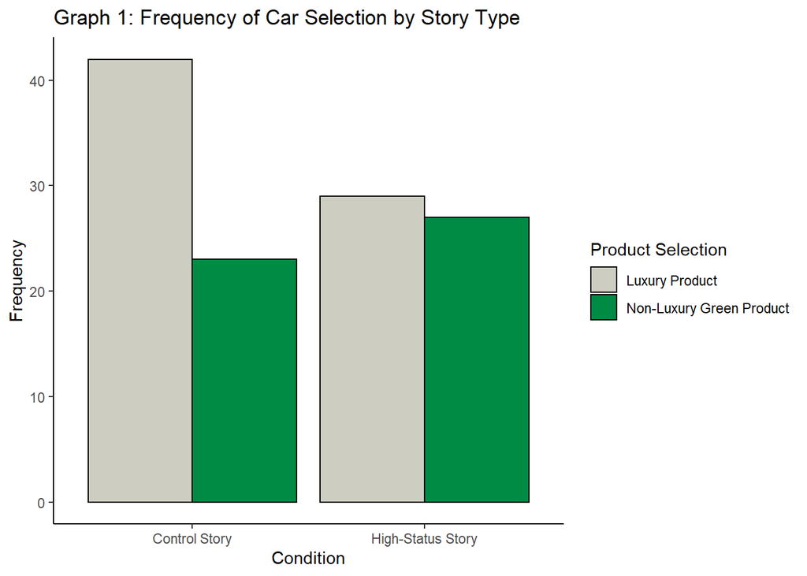

## Dishwasher

The data collected from the choice of dishwasher, however, shows that a higher proportion of participants selected the non-luxury green product in the high-status condition, with 52%, than the control condition, at 28%. This increase suggests that the high-status story did had an effect on product selection. These counts are shown below.

Observed Frequencies of Dishwasher Selection by Story Type

|  | Luxury Product | Non-Luxury Green Product |
| --- | --- | --- |
| Control Story | 46 | 18 |
| High-Status Story | 27 | 29 |

The results from the chi-squared test, *χ*<sup>2</sup>(1) = 6.06, *p* = 0.014, show a statistically significant relationship between condition and product selection, as p<.05. The null hypothesis for this product can therefore be rejected.

The final data set for the dishwasher is represented in the bar plot below.

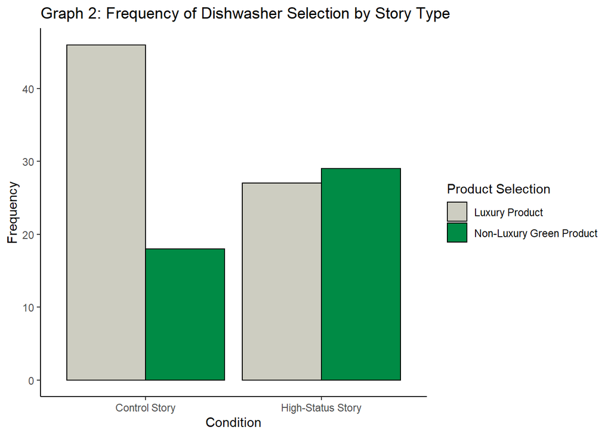

## Cleaner

Finally, in terms of the selection of cleaner, the data also suggests a possible relationship between story type and product chosen. In the control condition, 63% of participants selected the luxury product while the other 37% selected the non-luxury green product. However, in the high-status condition these figures appear to switch, with only 41% selecting the luxury product and 59% choosing the non-luxury green product. This is shown in the table below.

Observed Frequencies of Cleaner Selection by Story Type

|  | Luxury Product | Non-Luxury Green Product |
| --- | --- | --- |
| Control Story | 41 | 24 |
| High-Status Story | 23 | 33 |

After conducting a chi-squared test on this data, it was revealed that *χ*<sup>2</sup>(1) = 5, *p* = 0.025. Once again, the p-value is less than .05, thus he null hypotheis can be rejected again, as a statistically significant relationship between story type and product chosen can be inferred.

This is depicted in the following bar plot.

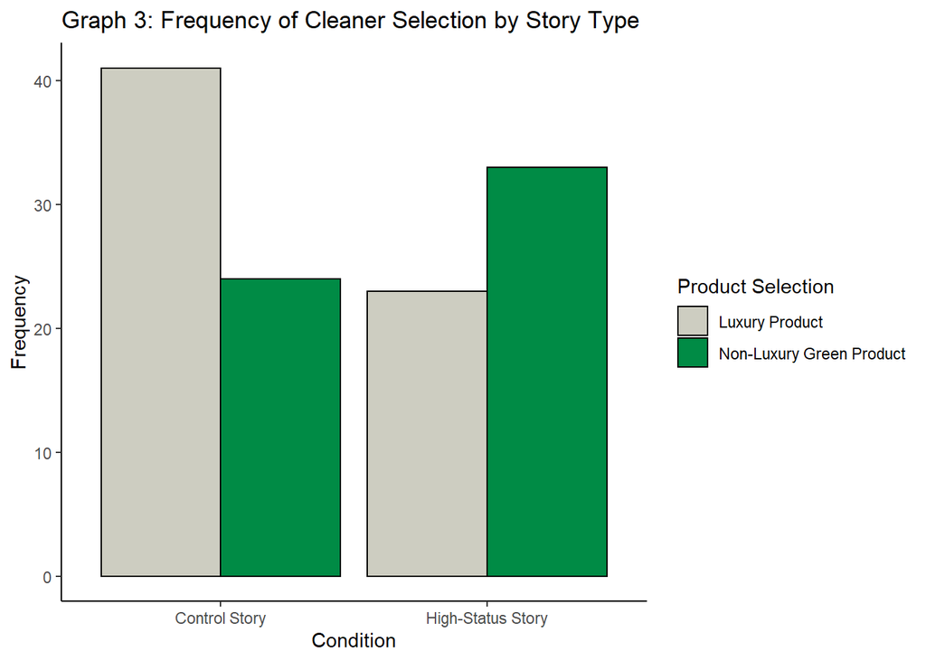

# Discussion

The overall result of this study tells us that triggering status motives can have an effect on a subsequent choice of either a luxury product or a more environmentally friendly alternative, thus supporting the hypothesis. For two out of the three products a statistically significant result was achieved, as the p-value was lower than the predetermined significance level of .05, meaning that the null hypothesis can be rejected. Despite this, it cannot be ignored that for one product, the car, no association was found. We cannot learn the reasons for this from the data set, but possible explanations could involve a higher desire for luxury cars than luxury cleaners and dishwashers. This too, however, could relate to status motives, as unlike the other two products, a car is not kept inside and will be seen by others. Therefore, having a luxury car may also be a way of promoting ones high-status. Contrarily, it is also possible that this statistical relationship between variables is simply not significant enough to have an impact on each occasion. It would be useful to conduct further research into the perceptions of different products in order to establish clear conclusions on this matter.

The results obtained through this study are very similar to those of Griskevicius, Tybur and Van den Bergh’s (2010) study into conspicuous consumption. Their findings demonstrated that through activating status motivations, the likelihood of people choosing non-luxury products with environmental benefits over luxury ones increased by up to 20% for all three products. Another study focusing on this effect is that of Hartmann and Apaolaza-Ibáñez (2012), who found that emphasizing the “warm glow” that comes from the awareness of an individual’s pro-environmental behaviour precipitated increased purchasing of green products. Through obtaining a similar general pattern of results, our study can be used as supporting evidence to confirm the effect of status awareness on pro-environmental behaviour. This can therefore be applied to real-world scenarios, such as marketing, to encourage such behaviour and consumerism, thus creating environmental benefits.

Although an effect was established in this study, possible design limitations could diminish the generalisability of this effect to wider populations and audiences. For example, the sample consisted of only a narrow range of ages, as all participants were between the age of 19 and 29. This means that how those above the age of 30 will react to this effect is unknown, as it cannot be assumed that people of all ages will behave in the same way. The fact that all participants are young adults may impact the data as they may have different opinions of what is important. For example, they may perceive having a luxury car as more desirable than someone who is older might, while both the young and the old may have different views on the importance of environmental preservation. Furthermore, although the use of a between-subjects design limits the chances of any order effects or demand characteristics, the effects of individual differences may have acted as a confounding variable and influenced the final results. It may have been that participants in the high-status condition were already more environmentally conscious than those in the control group, which would limit the extent to which we could say that the story type received had an impact. Because of this, we cannot be sure how strong the internal validity of the experiment really is. Finally, the fact that the study took place in a controlled laboratory environment means we can only be sure of how participants would react in other settings of the same nature. We are therefore unable to comment on the decisions they may make when faced with the actual purchasing of a product, as different decisions may be made based on the alternate situational factors. These limitations are problematic because, in order for the research findings to be beneficial to society, we must be able to generalise them to whole populations. We can only do this if we know for certain that the effect is genuine.

This research question is important as it there is an increasing demand for the production of more pro-environmental alternatives to every-day products due to increasing awareness of the ongoing “climate crisis” (Archer & Rahmstorf, 2010). Subsequent experiments allowing for the collection of quantitative data on this subject may help companies understand consumer motivation, so they can adapt their advertising techniques and focuses towards green products in order to increase sales and reduce the harm that other non-green products have on the environment. Because of this, it is worth conducting future studies that act upon the limitations of this one. For example, different sampling methods should be used so a more proportionate range of ages can be collected, such as that used by Hartmann and Apaolaza-Ibáñez (2012), who used quota controls in order to gather participants between the ages of 20 and 65, thus guaranteeing a representative age distribution within their sample. Furthermore, research could focus on factors that may have an effect on consumer behaviour, such as research from Anderson, Hildreth and Howland (2015), which investigated self-esteem and health rather than focusing just on status. That way, a more complete picture can be built surrounding the nature of consumer behaviour. Another suggestion for future research is to focus on the differing perceptions of product types. For example, Griskevicius, Tybur and Van den Bergh (2010) suggest that motives behind purchasing products that have more visibility, such as cars and clothing, are more likely to be influenced by a desire to promote high-status and worth. Investigation of this topic may provide insight into the lack of association for the ‘Car’ selection in this study.

The general pattern that emerged in this study was that by reading the high-status story and getting participants to consider their own status and motivations, they would be more inclined to then choose a more pro-environmental product in order to portray their own prosocial behaviour. The factors influencing product choice is a widely researched area in terms of consumerism, marketing, and campaigns for environmental protection, and these findings may therefore be valuable to each of these areas. Further research into factors other than status would also provide beneficial insight into how encouraging pro-environmental behaviour can be achieved in order to limit the escalating issue of climate damage.

# References

Anderson, C., Hildreth, J. A. D., & Howland, L. (2015, March 16). Is the Desire for Status a Fundamental Human Motive? A Review of the Empirical Literature. Psychological Bulletin. Advance online publication.

Archer, D., & Rahmstorf, S. (2010). The climate crisis: an introductory guide to climate change. Cambridge, UK: Cambridge University Press.

Griskevicius, V., Tybur, J. M., & Van den Bergh, B. (2010). Going green to be seen: Status, reputation, and conspicuous conservation. Journal of Personality and Social Psychology, 98, 343-355.

Hartmann, P., & Apaolaza-Ibáñez, V. (2012). Consumer attitude and purchase intention toward green energy brands: The roles of psychological benefits and environmental concern.

Steg, L., Bolderdijk, J. W., Keizer, K., & Perlaviciute, G. (2014). An integrated framework for encouraging pro-environmental behaviour: The role of values, situational factors and goals. Journal of Environmental psychology, 38, 104-115.

*** WORD LIMIT REACHED ***